# HW5

# Problem 5A

Suppose that $X_1, X_2, ..., X_{25}$ are i.i.d $N(\mu,\sigma^2)$ where $\mu = 0$ and $\sigma = 10$. Plot the sampling distributions of $\bar{X}$ and $\hat{\sigma^2}$.

$\mathbb{E}[\bar{X}] = \mathbb{E}[\frac{1}{25}\sum_{i=1}^{25}(X_i)]=[\frac{1}{25}\sum_{i=1}^{25}\mathbb{E}[X_i]=0$

$Var(\bar{X}) = Var(\frac{1}{25}\sum_{i=1}^{25}X_i)=[\frac{1}{25^2}\sum_{i=1}^{25}Var(X_i)]=\frac{10^2}{25^2}=0.16$

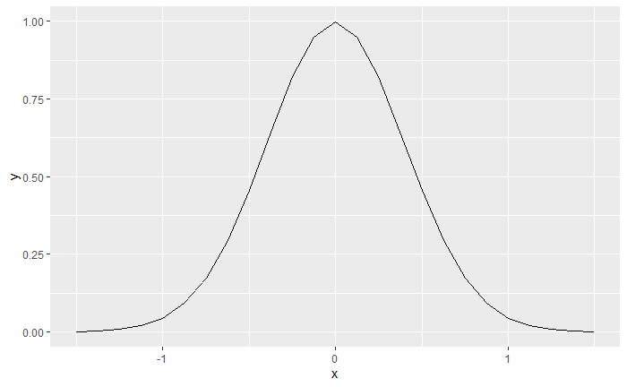

```r
library(ggplot2)
p1 <- ggplot(data.frame(x = c(-1.5,1.5)),aes(x))+
  stat_function(fun=dnorm, n=25, args=list(mean=0, sd=0.4))
p1
```

$\hat{\sigma}^2$

$\hat{\sigma}^2 = \frac{1}{n}\sum_{i=1}^{n}(X_i-\bar{X})^2=\frac{n-1}{n}\frac{1}{n-1}\sum_{i=1}^{n}(X_i-\bar{X})^2=\frac{n-1}{n}s^2$

$\Downarrow$

$s^2 = \frac{n}{n-1}\hat{\sigma}^2$

$\frac{(n-1)s^2}{\sigma^2} \sim \chi_{n-1}^2 \Rightarrow \frac{n \hat{\sigma}^2}{\sigma^2} \sim \chi_{n-1}^2$

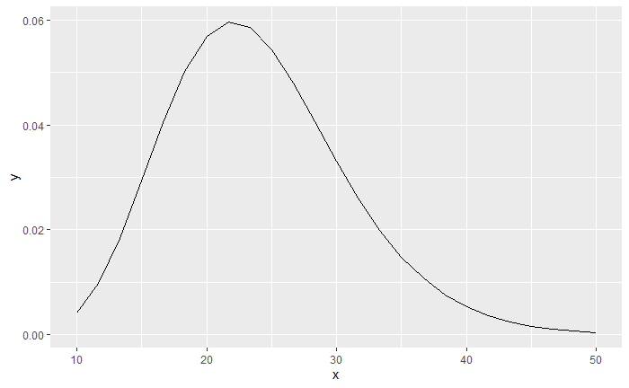

```r
library(ggplot2)
p2 <- ggplot(data.frame(x = c(10,50)),aes(x))+
  stat_function(fun=dchisq, n=25, args=list(df=24))
p2
```

# Problem 5G

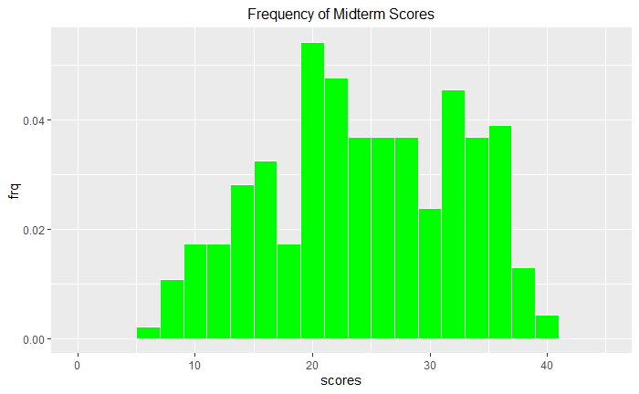

```r
scoreraw <- read.delim("/Users/sethc/Documents/Berkeley Fall2023/STAT 135/data.scores.txt",sep='',header=TRUE)
score <- scoreraw[scoreraw$f >0& scoreraw$m >0,]
score$m = score$m *2
score <- score[, c("m","f")]

#mid
ggplot(score, aes(x=m))+ geom_histogram(aes(y=..density..), binwidth=2, colour="white", fill ="green")+
  ggtitle("Frequency of Midterm Scores")+
  theme(plot.title=element_text(size=12, hjust=0.5))+
  xlab("scores")+
  ylab("frq")+
  xlim(c(0,45))
```

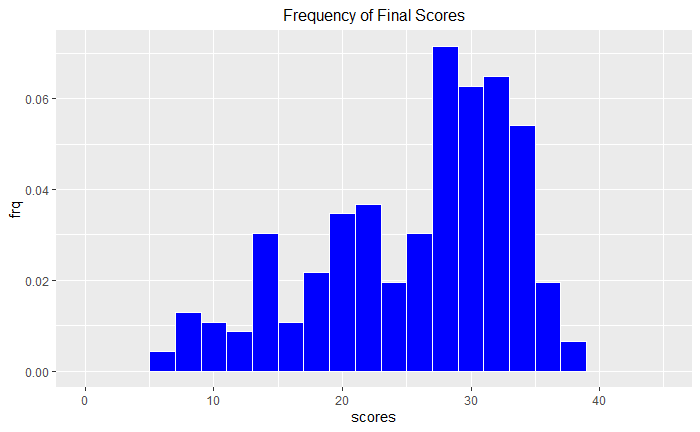

```r
#fin
ggplot(score, aes(x=f))+ geom_histogram(aes(y=..density..), binwidth=2, colour="white", fill ="blue")+
  ggtitle("Frequency of Final Scores")+
  theme(plot.title=element_text(size=12, hjust=0.5))+
  xlab("scores")+
  ylab("frq")+
  xlim(c(0,45))
```

```r
#box
# for some reaon it is not letting me use tidy
#library(tidyr)
#score_box <- gather(score,key ="exam",value ="scores", m, f)
#ggplot(score_long)+
  #geom_boxplot(aes(x=exam,y=scores))+
  #ggtitle("Midterm Scores vs Final Scores Distribution")+
  #theme(plot.title=element_text(size=12, hjust =0.5))
```

# Problem 5H

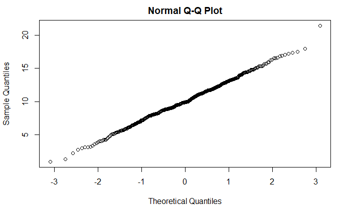

```r
set.seed(1)

# a)
nsample <- rnorm(500,mean=10,sd=3)
qqnorm(nsample)
```

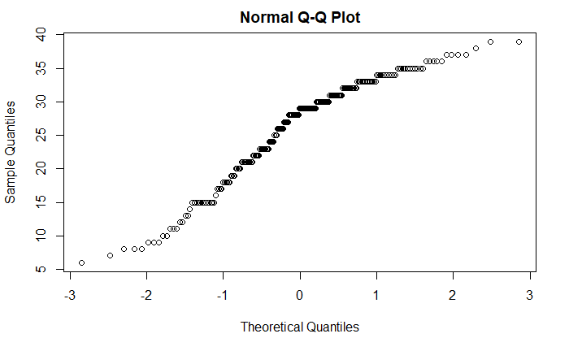

```r
# b)
qqnorm(score$f)
```

# Problem 5I

```r
stem(score$f)
```

```
  The decimal point is at the |

   6 | 00
   8 | 000000
  10 | 00000
  12 | 0000
  14 | 00000000000000
  16 | 00000
  18 | 0000000000
  20 | 0000000000000000
  22 | 00000000000000000
  24 | 000000000
  26 | 00000000000000
  28 | 000000000000000000000000000000000
  30 | 00000000000000000000000000000
  32 | 000000000000000000000000000000
  34 | 0000000000000000000000000
  36 | 000000000
  38 | 000
```

```r
stem(score$f, scale=0.5)
```

```
  The decimal point is 1 digit(s) to the right of the |

  0 | 67888999
  1 | 0011122334
  1 | 5555555555555677778888889999
  2 | 000001111111111122222223333333333444444
  2 | 55566666666777777888888888888999999999999999999999
  3 | 00000000000000011111111111111222222222222223333333333333333444444444
  3 | 555555555555666667777899
```

```r
stem(score$f, scale=2)
```

```
  The decimal point is at the |

   6 | 0
   7 | 0
   8 | 000
   9 | 000
  10 | 00
  11 | 000
  12 | 00
  13 | 00
  14 | 0
  15 | 0000000000000
  16 | 0
  17 | 0000
  18 | 000000
```

[output cut: 21 more lines]

It seems that the default stem and leaf plot seems to be the easiest to visually use, however I think that the last stem and leaf plot can also be used if exact grading distribution would like to be seen. Overall, I think the first one and the last one are significantly better than the middle one because it does not allow you to see the distribution of the scores for the exam and is too complicated visually while looking at it.

# Problem 5J

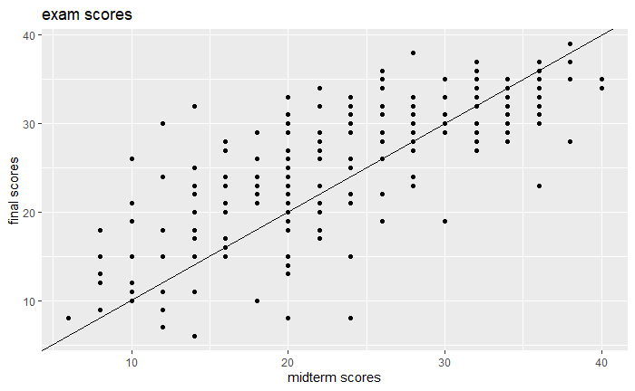

```r
ggplot(score, aes(x=m,y=f))+
  geom_point()+
  ggtitle("exam scores")+
  xlab("midterm scores")+
  ylab("final scores")+
  geom_abline()
```

```r
c <- sum(score$m<score$f)
c
```

```
[1] 137
```

```r
# [1] 137
```

The amount of people that did better due to the grading curve was 137 students.

A line that is more in line with the actual distribution of the grades would fit better. Estimation using m=1 for the slope of the line is not a good fit because the line is left with over 50% of the data lying above the line, a smaller slope or moving the line above the 0 intercept would be a better choice.